# Sampling

```python
###Packages
import pandas as pd
import numpy as np
import matplotlib.pyplot as plt
import matplotlib.mlab as mlab
from IPython.display import Image
from IPython.core.display import HTML
import datetime
import math
import scipy.optimize as optimize
import statistics
from sklearn.linear_model import LinearRegression
import statsmodels.api as sm
from statsmodels.formula.api import ols
from statsmodels.stats.anova import anova_lm
from scipy import stats
import scipy
import warnings
from scipy.stats import norm
warnings.filterwarnings('ignore')
plt.style.use('ggplot')
```

```python
### data loading & cleaning
df = pd.read_csv('./data/loan.csv', low_memory=False)
df = df.drop_duplicates(subset='id').reset_index(drop=True)
df.replace([np.inf, -np.inf], np.nan)
df = df.dropna(subset=['id', 'funded_amnt','int_rate','installment','grade'])
```

```python
###changing data type to appropriate date type
df['last_pymnt_d']=pd.to_datetime(df.last_pymnt_d)
df['issue_d']=pd.to_datetime(df.issue_d)
```

```python
###fill missing last_payments(no payments) with issue date, may want a separete column for this treatment
###This is for calculation of IRRs later
df['last_pymnt_d'].fillna(df.issue_d,inplace=True)
```

```python
###Some pre-processing for ease of calculations
df['issue_yr'] = df.issue_d.dt.year
df['issue_mo']= df.issue_d.dt.month
df['last_pymnt_yr'] = df.last_pymnt_d.dt.year
df['last_pymnt_mo']= df.last_pymnt_d.dt.month
df['mo_diff'] = pd.to_numeric((df['last_pymnt_yr'] -
                          df['issue_yr'])*12 + df['last_pymnt_mo'] -df['issue_mo'])
```

```python
###Flag for completed loans
searchfor = ['Fully Paid', 'Charged Off', 'Default']
defaults = ['Charged Off', 'Default']
df['loan_completion_flag']=  np.where(df['loan_status'].str.contains('|'.join(searchfor)) ,1, np.nan)
###Flag for fully paid loans
df['fully_paid'] = np.where(df['loan_status'].str.contains('Fully Paid') ,1,
                                  np.where(df['loan_status'].str.contains('|'.join(defaults)) ,0,np.nan))
```

```python
###Average payment = Total payment - recoveries - last payment amount over the life -1 month of the investment
df['avg_pymnt'] = (df['total_pymnt']-df['recoveries']-df['last_pymnt_amnt'])/(np.maximum((df['mo_diff']-1),0))
###Treating infinites that appear when there is no payment or only 1 payment
df['avg_pymnt'] = (df['avg_pymnt']).replace(np.Inf,0)
df['avg_pymnt'] = (df['avg_pymnt']).replace(-np.Inf,0)
```

```python
###IRR calculations
###Input: a row of a dataframe with lending data
def irr_calc(x):
    ##varible initialization
    initial_invest = -x['funded_amnt']
    avg_payment = x['avg_pymnt']
    num_payments = np.max(int(x['mo_diff'])-1,0)
    recovery = x['recoveries'] -x['collection_recovery_fee']
    recovery_duration = np.maximum(36 - num_payments + 1 + 12,12)
    avg_recovery = recovery/recovery_duration
    last_payment_amount = x['last_pymnt_amnt']
    ###IRR calculation, input: series of cash flows, total payment - recoveries
    ###evenly divided and spread across the life of the loan and finally recovery and chargeoff fees
    return ((np.irr([initial_invest]+[avg_payment]*num_payments + [last_payment_amount] +
                    [avg_recovery]*recovery_duration)+1)**12-1)
```

```python
###Calculating at a row level, individual security IRRs. Method will be faulty for loans that didn't mature.
###Warning: the calculation takes a fair amount of time ~few minutes
df['irr']=df.apply(irr_calc, axis=1)
```

```python
##NaNs returned from IRRs with 0 payments should be -100% return
df['irr']=df['irr'].replace(np.NaN,-1)
```

```python
####Filter down to completed loans and has at least 36 months of possible history
df_filtered = df[df['loan_status'].str.contains('|'.join(searchfor))].query("term == ' 36 months' and issue_yr <=2012").copy()
```

# Peer-to-Peer Lending Markets Part 1. Using Simple Random Sampling to Gain Insight on Investment Returns

Peer-to-peer lending introduced a new form of a debt market that investors can participate in. While these investments offer much higher returns than traditional debt market assets, they are prone to incredibly high defaults, more than 10% on average. Savvy investors should diversify away their exposure to loan defaults by investing in a variety of loans. We will employ simple random sampling to answer the question of how many loans should you invest in to reliably be free of the default risk.

For this exercise, we will be using the Lending Club dataset from Kaggle, https://www.kaggle.com/wendykan/lending-club-loan-data. Additionally, we will only look at loans that have complete loan information (either defaulted or fully paid).

Next, we ask how we are measuring the returns. Interest rate provided is a poor measure because it doesn't take into consideration of the default rate. Instead, we will use the Internal Rate of Return, which essentially calculates the discount rate that would net all the cash flows to zero net present value. Below is how the distribution of these returns look like.

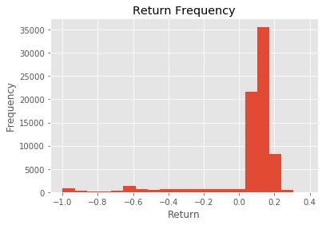

```python
####Histogram of returns
plt.hist(df_filtered['irr'],bins=20)
plt.xlabel('Return')
plt.ylabel('Frequency')
plt.title('Return Frequency')
plt.show()
```

Distribution of the lending returns is not normal and heavily skewed to the left. Extreme losses are possible. Again, pooling loans to spread the default risk out is a key to a successful investment strategy. Below we will look at the performances of 100 randomly selected loans using simple random sampling and look at its sample distribution mean and variance. We will conduct 100 trials to collect 100 different portfolios of 100 randomly chosen loans.

```python
def cash_flow(row,max_n):
    initial_invest = -row['funded_amnt']
    avg_payment = row['avg_pymnt']
    num_payments = np.max(int(row['mo_diff'])-1,0)
    recovery = row['recoveries'] -row['collection_recovery_fee']
    recovery_duration = np.maximum(36 - num_payments + 1 + 12,12)
    avg_recovery = recovery/recovery_duration
    last_payment_amount = row['last_pymnt_amnt']
    dummy_cfs = int(max_n -(1+num_payments+recovery_duration))
    return [initial_invest]+[avg_payment]*num_payments+[last_payment_amount]+[avg_recovery]*recovery_duration+ [0]*dummy_cfs
```

```python
def irr_pool(df):
    list_length = df['mo_diff'].max()+12
    cfs=[]
    for index, row in df.iterrows():
        cfs.append(cash_flow(row,list_length))
    result = [sum(x) for x in zip(*cfs)]
    return (np.irr(result)+1)**12 -1
```

```python
def collect_n_random_stats(df,n,size):
    returns_list = []
    for x in range(0,n):
        df_out = df.sample(size,replace=False)
        returns_list.append(irr_pool(df_out))
    return [np.average(returns_list)] +[math.sqrt(np.var(returns_list))]
```

```python
def collect_n_random_stats_raw(df,n,size):
    returns_list = []
    for x in range(0,n):
        df_out = df.sample(size,replace=False)
        returns_list.append(irr_pool(df_out))
    return returns_list
```

```python
####Collect 100 samples of 100 loans(~1M in exposure)
out=collect_n_random_stats(df_filtered,100,100)
```

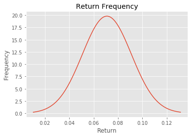

```python
mu = out[0]
sigma = out[1]
x = np.linspace(mu - 3*sigma, mu + 3*sigma, 100)
plt.plot(x,mlab.normpdf(x, mu, sigma))
plt.xlabel('Return')
plt.ylabel('Frequency')
plt.title('Return Frequency')
plt.show()
```

```python
##### See how the risk-adjusted returns have changed over the years
size_series  = []
for size in (10,100,1000,4000):
    size_series += [collect_n_random_stats_raw(df_filtered,100,size)]
```

```python
final = pd.DataFrame({'$250':size_series[0] , '$2,500':size_series[1], '$25,000' : size_series[2], '$100,000':size_series[3]})
final = final[['$250','$2,500','$25,000','$100,000']]
```

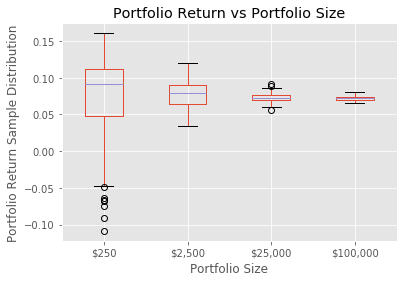

```python
final.boxplot()
plt.xlabel('Portfolio Size')
plt.ylabel('Portfolio Return Sample Distribution')
plt.title('Portfolio Return vs Portfolio Size')
plt.show()
```

If you invested into 1000 different loans or more, you would have almost surely been profitable. In contrast, you could have lost up to 10% or even more, if you were particularly unlucky, had you invested in just 10 loans. Basically, you should invest into as many loans as your budget allows.

So far, we conducted the analysis using a completely blind random sample strategy. What if we can build a model that can choose the right loans for us? Theoretically, with an alpha generating model, we should be able to build a portfolio that will not only give us strong confidence in achieving a positive return but also help us outperform the market. In the next part of this series, I will explore leveraging different machine learning algorithms to help us select loans and outperform the market.

Code base for this project can be found here: https://github.com/yjs1210/lending-tree